# Análisis del Gasto en Servicios Dentales

# Introducción

Este análisis se centra en el gasto en **servicios dentales curativos o de rehabilitación** (CCIF `06.2.2.09.01`), que incluyen consultas, procedimientos y tratamientos dentales no hospitalarios realizados por profesionales como dentistas, endodoncistas, ortodoncistas, cirujanos maxilofaciales, entre otros.

El servicio contempla tanto tratamientos clínicos como urgencias, empastes, endodoncias, implantes, prótesis y ortodoncia, así como sus insumos asociados. Se excluyen los servicios preventivos y productos médicos cobrados por separado.

Se seleccionó este servicio por su relevancia social y por las claras desigualdades en el acceso, fuertemente determinadas por el ingreso y la escolaridad. Además, presenta una distribución adecuada para un modelo de dos partes, con muchos hogares sin gasto y montos altos entre quienes sí acceden.

# Código

## 1. Librerías necesarias

Para desarrollar correctamente el trabajo, se cargaron las principales librerías necesarias:

```r
# --- LIBRERÍAS ---
library(haven)
library(ggplot2)
library(pROC)
library(corrplot)
```

## 2. Carga y preparación de las bases

Se cargaron las bases de datos `personas` y `gastos` de la EPF. Luego, se filtraron las observaciones correspondientes a la macrozona 2 (Gran Santiago) y se consideraron únicamente las personas principales del hogar, ya que los servicios de salud suelen registrarse bajo su responsabilidad económica.

```r
# --- CARGA DE BASES ---
personas <- read_dta("../data/datos_epf/base-personas-ix-epf-stata.dta")
gastos   <- read_dta("../data/datos_epf/base-gastos-ix-epf-stata.dta")

# --- FILTRO: GRAN SANTIAGO Y PERSONAS PRINCIPALES (servicio) ---
personas_gs <- subset(personas, macrozona == 2 & sprincipal == 1)
```

## 3. Limpieza básica y creación de variables

Se eliminaron observaciones con valores inválidos en edad, escolaridad e ingreso. A partir del ingreso disponible del hogar y el tamaño del hogar, se construyó la variable `ing_pc` (ingreso per cápita). Además, se categorizó la escolaridad en cuatro niveles (`grupo_escolaridad`) para facilitar la interpretación en los modelos.

```r
# --- LIMPIEZA BÁSICA ---
valores_invalidos <- c(-99, -88, -77)
personas_gs <- subset(personas_gs,
                      !(edad %in% valores_invalidos) &
                        !(edue %in% valores_invalidos) &
                        ing_disp_hog_hd_ai >= 0)

# --- VARIABLES DERIVADAS ---
personas_gs$ing_pc <- personas_gs$ing_disp_hog_hd_ai / personas_gs$npersonas
personas_gs$grupo_escolaridad <- cut(personas_gs$edue,
                                     breaks = c(-Inf, 8, 12, 16, Inf),
                                     labels = c("Básica o menos", "Media-baja", "Media-alta", "Alta"),
                                     right = TRUE)
```

## 4. Obtención del gasto del servicio dental

Se filtraron los registros de la base `gastos` asociados al código **CCIF `06.2.2.09.01`** (servicios dentales curativos o de rehabilitación). Luego, se **sumó el gasto total por hogar (`folio`)**, y se unió esa información a la base de personas mediante un `merge`. Se creó una nueva variable `gasto_dental` (monto total gastado) y una variable binaria `incurre_gasto` que indica si el hogar incurrió o no en gasto dental.

```r
# --- GASTO DENTAL: unir por folio asegurando tipo compatible ---
codigo_dental <- "06.2.2.09.01"
gastos_dental <- subset(gastos, ccif == codigo_dental & macrozona == 2)

# Asegurar tipo character en ambas tablas
personas_gs$folio <- as.character(personas_gs$folio)
gastos_dental$folio <- as.character(gastos_dental$folio)

# Gasto total por hogar
gasto_por_folio <- aggregate(gasto ~ folio, data = gastos_dental, sum)
names(gasto_por_folio)[2] <- "gasto_dental"

# Unión por folio
gasto_por_folio$folio <- as.character(gasto_por_folio$folio)
personas_gs <- merge(personas_gs, gasto_por_folio, by = "folio", all.x = TRUE)

# Reemplazar NA por 0
personas_gs$gasto_dental[is.na(personas_gs$gasto_dental)] <- 0
personas_gs$incurre_gasto <- ifelse(personas_gs$gasto_dental > 0, 1, 0)
```

## 5. Construcción de la base de análisis (`df_dental`)

Se creó una base intermedia que incluye solo observaciones con todas las variables explicativas válidas. Además, se transformó la variable `sexo` en un factor sin cambiar su nivel base (por defecto: `1 = hombre`), lo que permite interpretar los modelos comparando mujeres respecto a hombres.

```r
# --- BASE PRINCIPAL ---
df_dental <- subset(personas_gs,
                    !is.na(edad) & !is.na(grupo_escolaridad) &
                      !is.na(sexo) & !is.na(npersonas) & !is.na(ing_pc))
df_dental$sexo <- factor(df_dental$sexo)
```

## 6. Exploración inicial

Antes de aplicar los modelos, se realizó una exploración descriptiva del gasto dental privado utilizando la base `df_dental`, que contiene tanto a quienes gastaron como a quienes no. Se elaboraron histogramas para visualizar la distribución del gasto, boxplots para comparar montos según sexo, y gráficos de dispersión para observar posibles relaciones entre el gasto y variables como edad e ingreso per cápita.

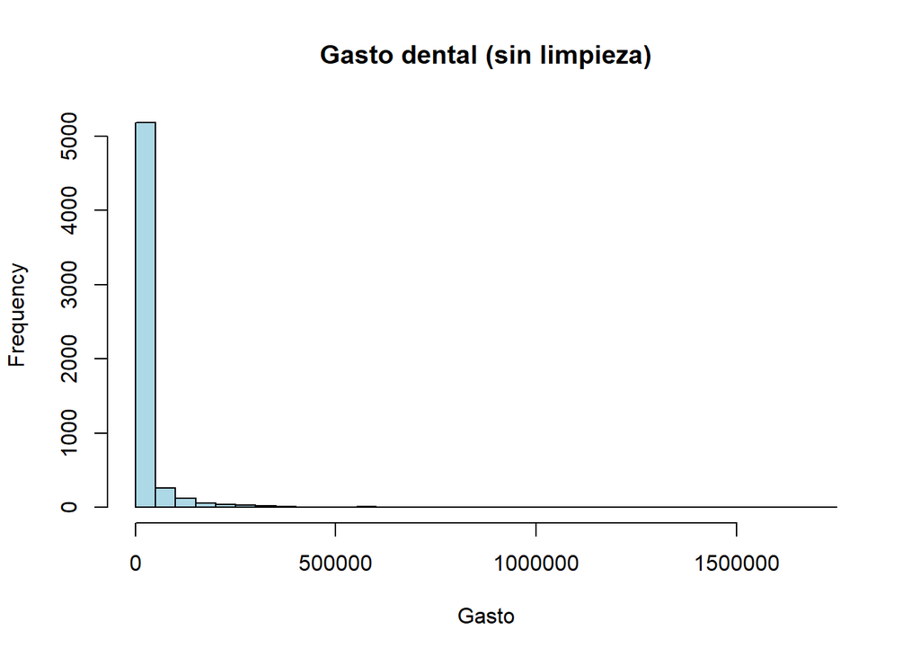

```r
hist(df_dental$gasto_dental, breaks = 30, col = "lightblue", main = "Gasto dental (sin limpieza)", xlab = "Gasto")
```

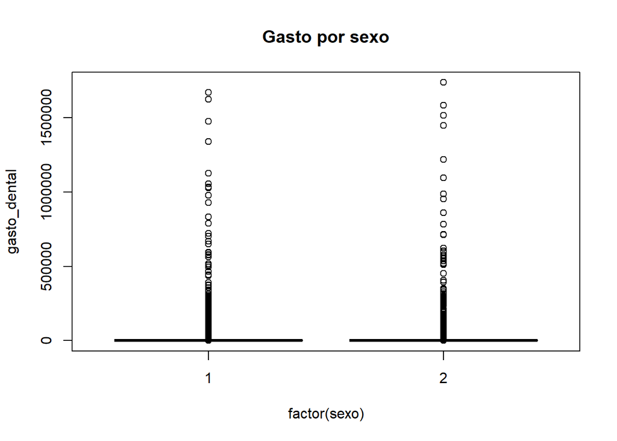

```r
boxplot(gasto_dental ~ factor(sexo), data = df_dental, main = "Gasto por sexo", col = c("tomato", "lightgreen"))
```

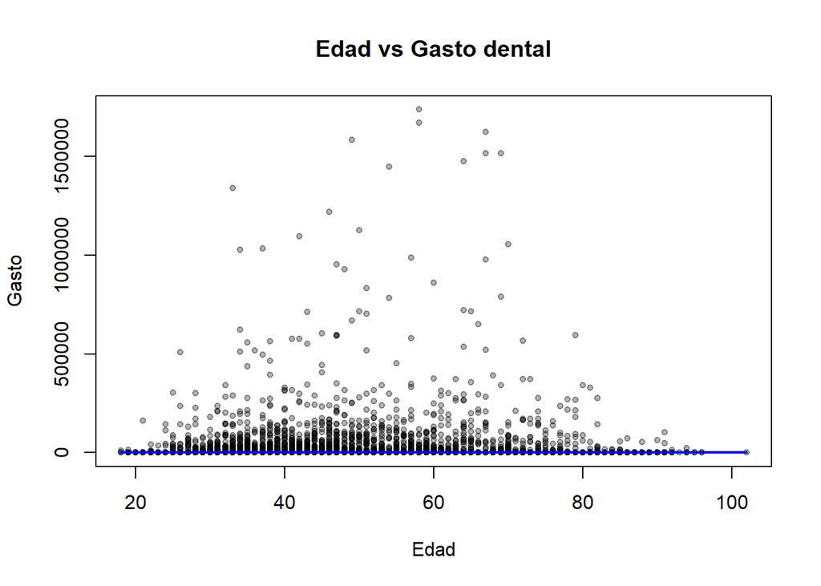

```r
plot(df_dental$edad, df_dental$gasto_dental, main = "Edad vs Gasto dental", xlab = "Edad", ylab = "Gasto", pch = 20, col = rgb(0,0,0,0.3))
lines(lowess(df_dental$edad, df_dental$gasto_dental), col = "blue", lwd = 2)
```

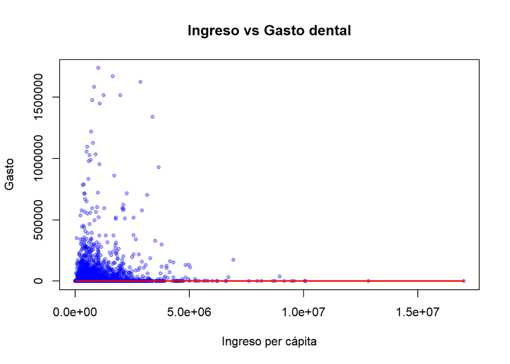

```r
plot(df_dental$ing_pc, df_dental$gasto_dental, main = "Ingreso vs Gasto dental", xlab = "Ingreso per cápita", ylab = "Gasto", pch = 20, col = rgb(0,0,1,0.3))
lines(lowess(df_dental$ing_pc, df_dental$gasto_dental), col = "red", lwd = 2)
```

## 7. Limpieza de valores atípicos

Debido a la alta dispersión del gasto entre quienes sí incurrieron en gasto dental, se aplicó una limpieza de valores atípicos (**outliers**) con el fin de mejorar la precisión del modelo lineal.

Se filtran solo los hogares que efectivamente incurrieron en gasto, para preparar el modelo lineal.

Se utilizó el método del **rango intercuartílico (IQR).**

```r
# --- LIMPIEZA DE OUTLIERS SOLO EN QUIENES SÍ GASTARON ---
df_dental_gastaron <- df_dental[df_dental$gasto_dental > 0, ]

limpiar_outliers <- function(x) {
  Q1 <- quantile(x, 0.25, na.rm = TRUE)
  Q3 <- quantile(x, 0.75, na.rm = TRUE)
  IQR <- Q3 - Q1
  lim_inf <- Q1 - 1.5 * IQR
  lim_sup <- Q3 + 1.5 * IQR
  return(x >= lim_inf & x <= lim_sup)
}

filtros <- with(df_dental_gastaron,
                limpiar_outliers(edad) &
                  limpiar_outliers(edue) &
                  limpiar_outliers(ing_pc) &
                  limpiar_outliers(gasto_dental) &
                  limpiar_outliers(npersonas))

df_dental_limpio <- df_dental_gastaron[filtros, ]
```

## 8. Exploración limpia

Eliminación de valores atípicos

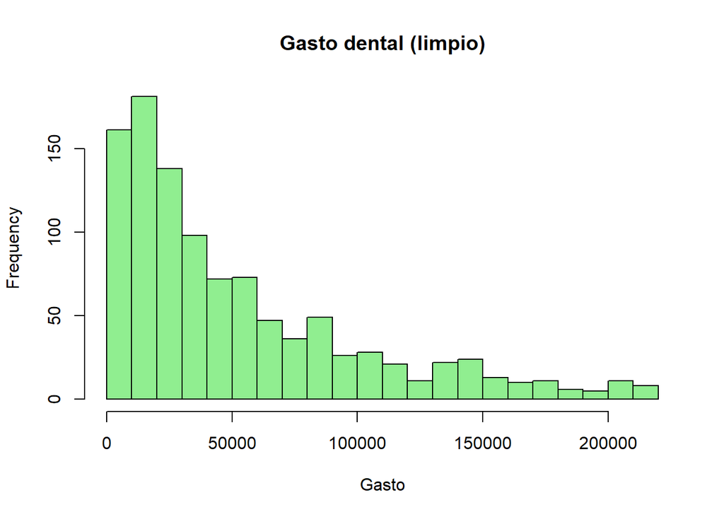

```r
hist(df_dental_limpio$gasto_dental, breaks = 30, col = "lightgreen", main = "Gasto dental (limpio)", xlab = "Gasto")
```

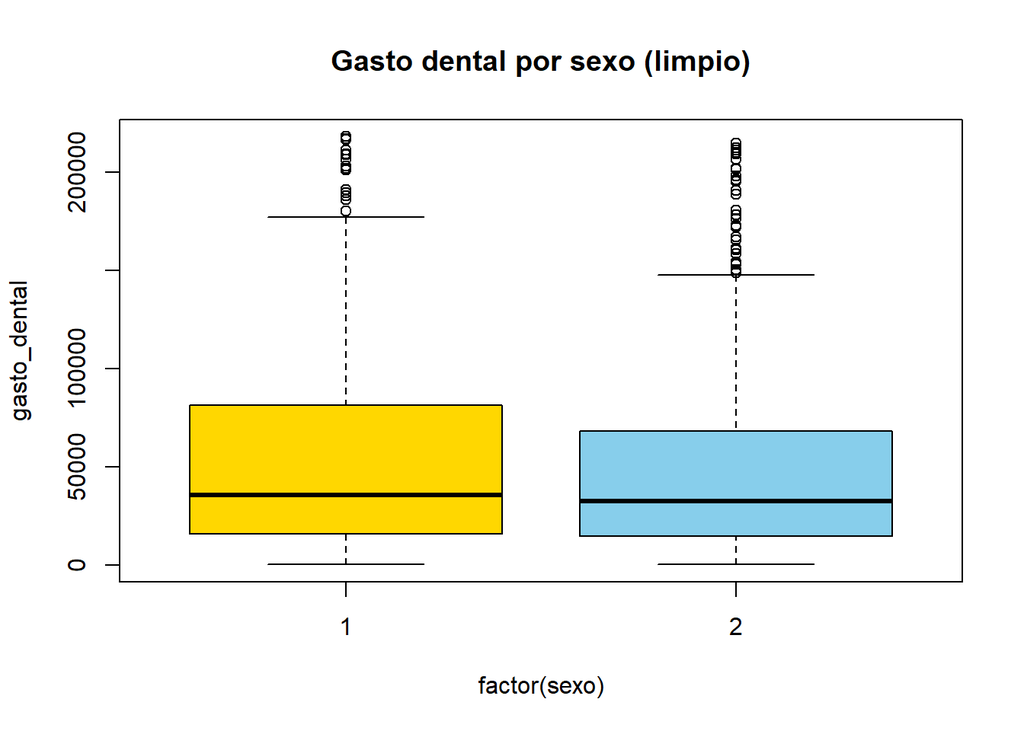

```r
boxplot(gasto_dental ~ factor(sexo), data = df_dental_limpio, main = "Gasto dental por sexo (limpio)", col = c("gold", "skyblue"))
```

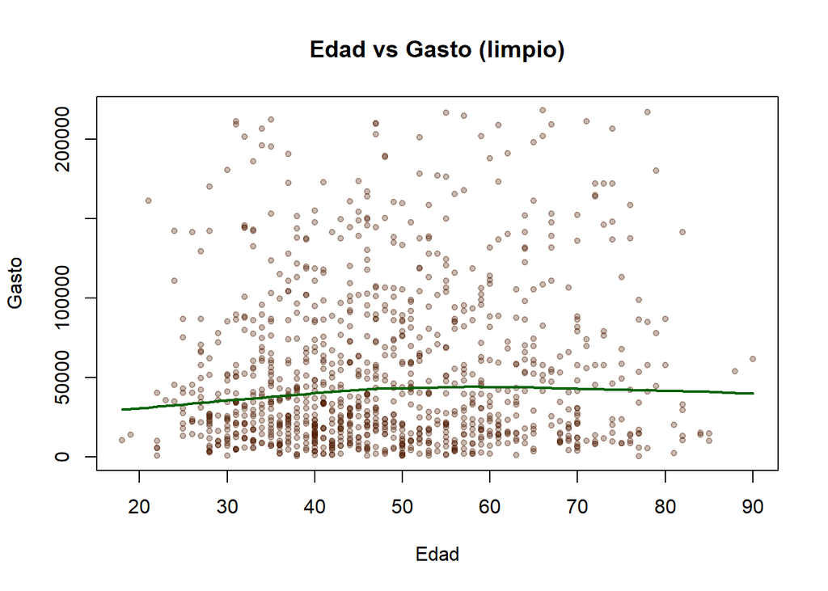

```r
plot(df_dental_limpio$edad, df_dental_limpio$gasto_dental, main = "Edad vs Gasto (limpio)", xlab = "Edad", ylab = "Gasto", pch = 20, col = rgb(0.3,0.1,0,0.3))
lines(lowess(df_dental_limpio$edad, df_dental_limpio$gasto_dental), col = "darkgreen", lwd = 2)
```

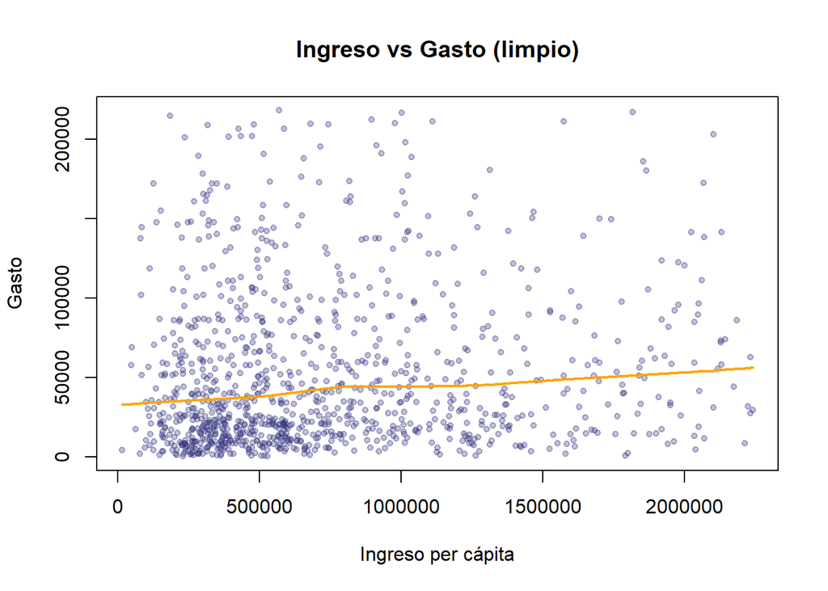

```r
plot(df_dental_limpio$ing_pc, df_dental_limpio$gasto_dental, main = "Ingreso vs Gasto (limpio)", xlab = "Ingreso per cápita", ylab = "Gasto", pch = 20, col = rgb(0.2,0.2,0.5,0.3))
lines(lowess(df_dental_limpio$ing_pc, df_dental_limpio$gasto_dental), col = "orange", lwd = 2)
```

## 9. Matriz de correlación

Se construyó una matriz de correlación de Pearson entre las variables explicativas y el gasto dental, utilizando únicamente las observaciones limpias. Esto permite identificar **relaciones lineales** entre variables y verificar redundancias o asociaciones esperadas (por ejemplo, entre ingreso y gasto).

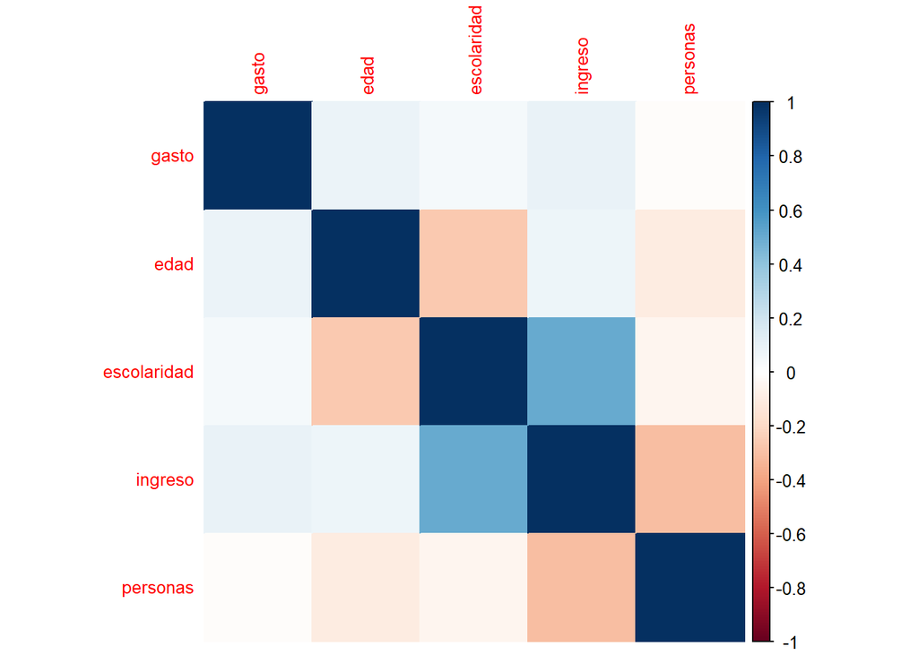

```r
# --- MATRIZ DE CORRELACIÓN ---
df_cor <- data.frame(
  gasto = df_dental_limpio$gasto_dental,
  edad = df_dental_limpio$edad,
  escolaridad = df_dental_limpio$edue,
  ingreso = df_dental_limpio$ing_pc,
  personas = df_dental_limpio$npersonas
)
cor_matrix <- cor(df_cor, use = "complete.obs", method = "pearson")
corrplot(cor_matrix, method = "color", tl.cex = 0.8, number.cex = 0.7)
```

## 10. Modelo Lineal

Se modeló el gasto en función de la escolaridad, ingreso per cápita, sexo, edad y tamaño del hogar. El modelo permite analizar qué factores explican mayores niveles de gasto, aunque, como es común en este tipo de datos, el R² obtenido fue bajo debido a la alta variabilidad individual.

```r
# --- MODELO LINEAL: monto gastado, solo con datos limpios ---
modelo_lineal <- lm(gasto_dental ~ edue + ing_pc + sexo + edad + npersonas,
                    data = df_dental_limpio)
summary(modelo_lineal)
```

```
##
## Call:
## lm(formula = gasto_dental ~ edue + ing_pc + sexo + edad + npersonas,
##     data = df_dental_limpio)
##
## Residuals:
##    Min     1Q Median     3Q    Max
## -64527 -35811 -16674  23122 168867
##
## Coefficients:
##               Estimate Std. Error t value Pr(>|t|)
## (Intercept)  2.530e+04  1.123e+04   2.253  0.02446 *
## edue         3.898e+02  5.656e+02   0.689  0.49092
## ing_pc       8.151e-03  3.791e-03   2.150  0.03175 *
## sexo2       -3.486e+03  3.090e+03  -1.128  0.25944
## edad         3.100e+02  1.164e+02   2.663  0.00787 **
## npersonas    6.435e+02  1.139e+03   0.565  0.57210
## ---
## Signif. codes:  0 '***' 0.001 '**' 0.01 '*' 0.05 '.' 0.1 ' ' 1
##
## Residual standard error: 49050 on 1045 degrees of freedom
## Multiple R-squared:  0.01837,    Adjusted R-squared:  0.01367
## F-statistic: 3.912 on 5 and 1045 DF,  p-value: 0.001615
```

El modelo permite concluir que el ingreso per cápita y la edad son determinantes significativos del monto gastado en servicios dentales privados. Sin embargo, otros factores como sexo, escolaridad o tamaño del hogar no resultaron significativos, lo que sugiere que el monto gastado depende más de factores económicos y necesidades individuales que de características sociodemográficas amplias.

## 11. Modelo logit

El objetivo fue analizar qué factores están asociados a tener o no gasto en atención dental privada. Las variables explicativas fueron: sexo, edad, escolaridad agrupada, ingreso per cápita y número de personas en el hogar.

```r
# --- MODELO LOGIT: probabilidad de incurrir en gasto dental ---
modelo_logit <- glm(incurre_gasto ~ factor(sexo) + edad + grupo_escolaridad + ing_pc + npersonas,
                    data = df_dental, family = binomial)
summary(modelo_logit)
```

```
##
## Call:
## glm(formula = incurre_gasto ~ factor(sexo) + edad + grupo_escolaridad +
##     ing_pc + npersonas, family = binomial, data = df_dental)
##
## Coefficients:
##                               Estimate Std. Error z value Pr(>|z|)
## (Intercept)                 -2.573e+00  2.024e-01 -12.716  < 2e-16 ***
## factor(sexo)2                1.101e-01  6.580e-02   1.673  0.09441 .
## edad                         2.799e-04  2.333e-03   0.120  0.90449
## grupo_escolaridadMedia-baja  5.298e-01  1.177e-01   4.502 6.73e-06 ***
## grupo_escolaridadMedia-alta  1.046e+00  1.235e-01   8.472  < 2e-16 ***
## grupo_escolaridadAlta        1.249e+00  1.283e-01   9.740  < 2e-16 ***
## ing_pc                       1.294e-07  3.970e-08   3.259  0.00112 **
## npersonas                    1.230e-01  2.120e-02   5.800 6.63e-09 ***
## ---
## Signif. codes:  0 '***' 0.001 '**' 0.01 '*' 0.05 '.' 0.1 ' ' 1
##
## (Dispersion parameter for binomial family taken to be 1)
##
##     Null deviance: 6113.7  on 5757  degrees of freedom
## Residual deviance: 5873.8  on 5750  degrees of freedom
## AIC: 5889.8
##
## Number of Fisher Scoring iterations: 4
```

El modelo logit evidencia que la escolaridad y el ingreso son los principales determinantes estructurales del acceso al servicio dental privado, reforzando la idea de que se trata de un bien de consumo desigual y condicionado por la posición socioeconómica.

```r
# AUC
probabilidades_logit <- predict(modelo_logit, type = "response")
roc_obj <- roc(df_dental$incurre_gasto, probabilidades_logit)
cat("AUC:", auc(roc_obj), "\n")
```

```
## AUC: 0.6436589
```

Un AUC de 0.644 indica que el modelo tiene una capacidad aceptable para clasificar correctamente, aunque con margen de mejora.

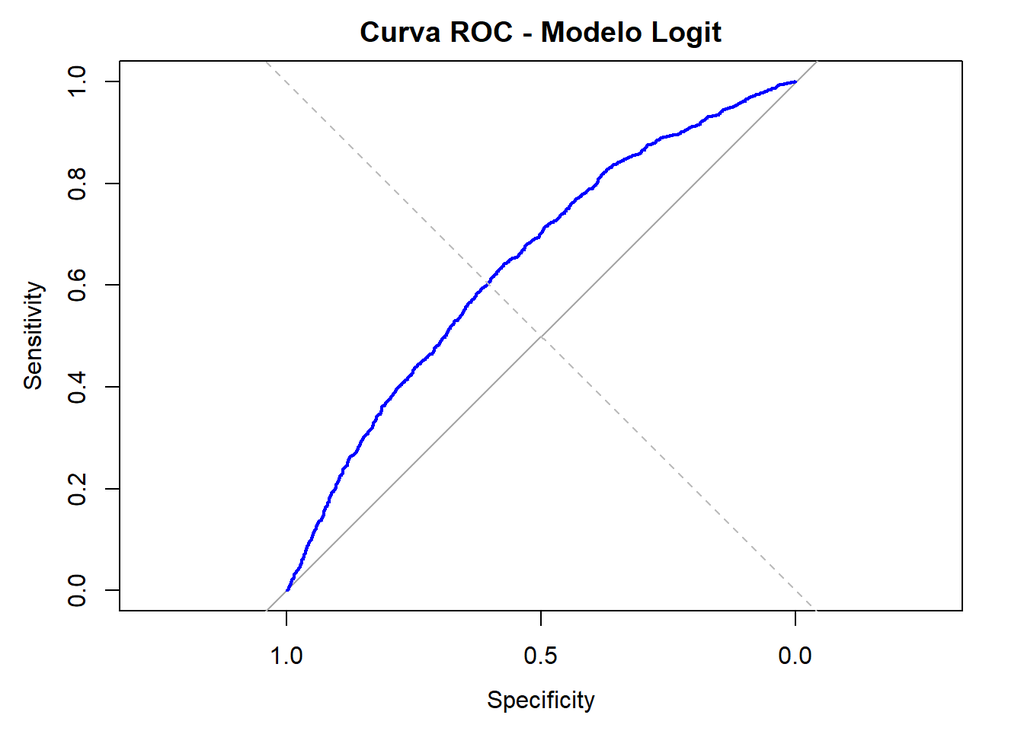

```r
# curva ROC
plot(roc_obj, col = "blue", main = "Curva ROC - Modelo Logit")
abline(a = 0, b = 1, lty = 2, col = "gray")
```

la curva no se acerca al vértice superior izquierdo (sensibilidad = 1, especificidad = 1), lo que refleja que el modelo **no es altamente preciso**, pero sí razonable dentro de un contexto social y con las variables disponibles.

El área bajo la curva ROC (AUC) fue de **0.644**, lo que refuerza esta interpretación: el modelo tiene una **capacidad aceptable para distinguir entre hogares que incurren y no incurren en gasto**, aunque con margen de mejora.

```r
# Pseudo-R² de McFadden
logLik_modelo <- logLik(modelo_logit)
logLik_nulo <- logLik(glm(incurre_gasto ~ 1, data = df_dental, family = binomial))
pseudo_R2 <- 1 - as.numeric(logLik_modelo / logLik_nulo)
cat("Pseudo-R² de McFadden:", round(pseudo_R2, 4), "\n")
```

```
## Pseudo-R² de McFadden: 0.0392
```

ajuste modesto.

| mejora | razón |
| --- | --- |
| Agregar más variables | Majora el poder explicativo |
| Probar log(gasto) | Reduce el sesgo en le regresión |
| Visualizaciones comparativas | Ayudan con el análisis |